# Stability Assignment

Try increasing the initial conditions:

```r
# times when you want to evaluate
days = seq(from=1,to=500)

# increasing initial populations
currpop=c(prey=100, pred=10)

# run differential equation solver
res = ode(func=lotvmod_hunt, y=currpop, times=days, parms=pars)
```

```
## DLSODA-  At current T (=R1), MXSTEP (=I1) steps
##       taken on this call before reaching TOUT
## In above message, I1 = 5000
##
## In above message, R1 = 25.0896
##
```

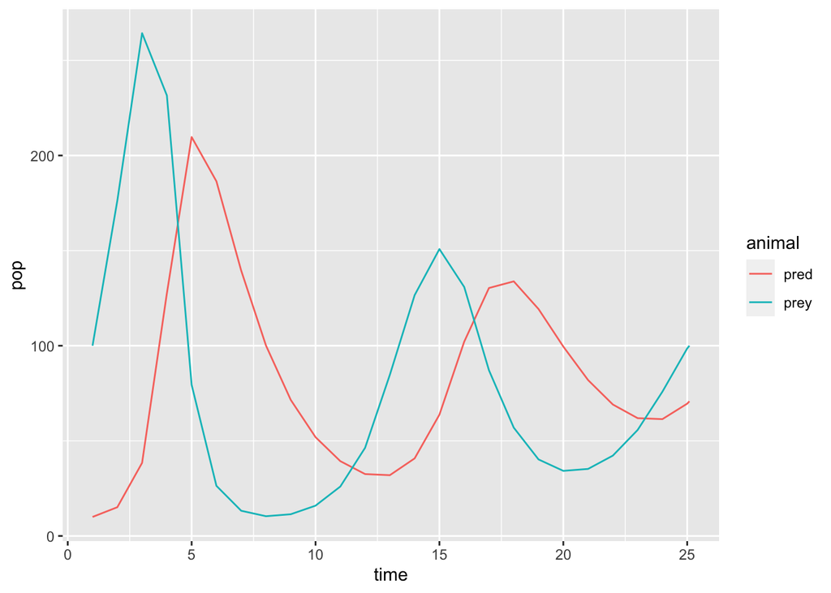

```r
# extract the results
res_initial = as.data.frame(res) %>% gather(key="animal", value="pop",-time)

# graph both populations over time
p3 = ggplot(res_initial,
          aes(time, pop, col=animal)) +
  geom_line()

p3
```

Interestingly that decreased populations even more

Now I’ll try going back to a 1 to 1 initial condition and messing with some of the other parameters

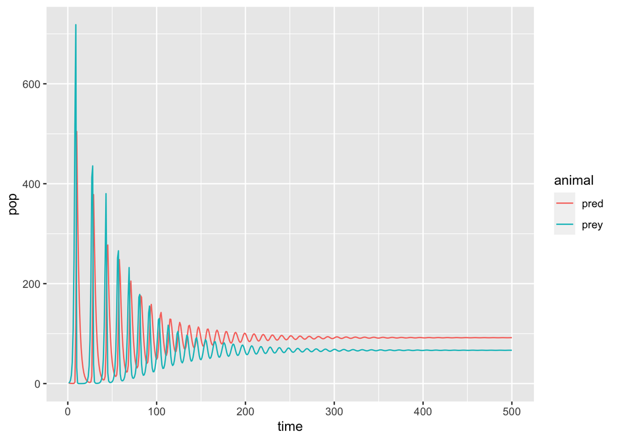

```r
# set new parameter list
pars = data.frame(rprey=0.95,
                  alpha=0.01,
                  eff=0.6,
                  pmort=0.4,
                  K=2000,
                  h = 0.02) #decreasing the hunting rate significantly

# time
days = seq(from=1,to=500)

# first see what happens when we start with 1 of each
currpop=c(prey=1, pred=1)

# run differential equation solver
res = ode(func=lotvmod_hunt, y=currpop, times=days, parms=pars)

# extract the results
res_initial = as.data.frame(res) %>% gather(key="animal", value="pop",-time)

# graph both populations over time
p4 = ggplot(res_initial,
          aes(time, pop, col=animal)) +
  geom_line()

p4
```

The lower hunting rate didn’t actually increase the populatin much at all, so instead I will leave a higher hunting rate and change the other parameters around

```r
# set new parameter list
pars = data.frame(rprey=0.98,
                  alpha=0.01,
                  eff=0.3,
                  pmort=0.2,
                  K=2000,
                  h = 0.9)

# time
days = seq(from=1,to=500)

# first see what happens when we start with 1 of each
currpop=c(prey=1, pred=1)

# run differential equation solver
res = ode(func=lotvmod_hunt, y=currpop, times=days, parms=pars)
```

```
## DLSODA-  At current T (=R1), MXSTEP (=I1) steps
##       taken on this call before reaching TOUT
## In above message, I1 = 5000
##
## In above message, R1 = 25.3101
##
```

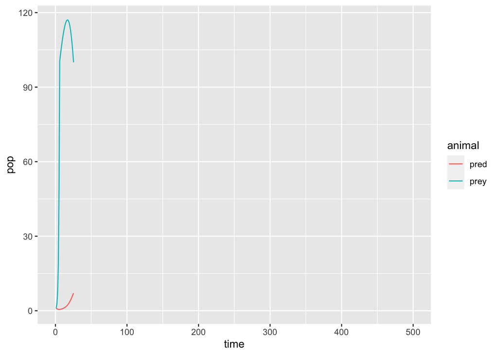

```r
# extract the results
res_initial = as.data.frame(res) %>% gather(key="animal", value="pop",-time)

# graph both populations over time
p5 = ggplot(res_initial,
          aes(time, pop, col=animal)) +
  geom_line() +
  scale_x_continuous(limits = c(0, 500))

p5
```

Playing around with the parameters a lot - having the hunting rate so high (as above) means that the prey population is pretty much only controlled by hunting and the predator population can grow over time - however they both dissappear after 25 days???

```r
# set new parameter list
pars = data.frame(rprey=1.2,
                  alpha=0.01,
                  eff=0.3,
                  pmort=0.2,
                  K=2000,
                  h = 0.2)

# time
days = seq(from=1,to=500)

# first see what happens when we start with 1 of each
currpop=c(prey=1, pred=1)

# run differential equation solver
res = ode(func=lotvmod_hunt, y=currpop, times=days, parms=pars)
```

```
## DLSODA-  At current T (=R1), MXSTEP (=I1) steps
##       taken on this call before reaching TOUT
## In above message, I1 = 5000
##
## In above message, R1 = 57.1666
##
```

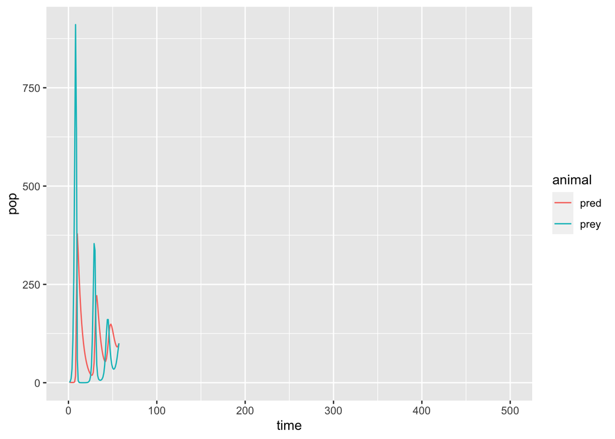

```r
# extract the results
res_initial = as.data.frame(res) %>% gather(key="animal", value="pop",-time)

# graph both populations over time
p6 = ggplot(res_initial,
          aes(time, pop, col=animal)) +
  geom_line() +
  scale_x_continuous(limits = c(0, 500))

p6
```

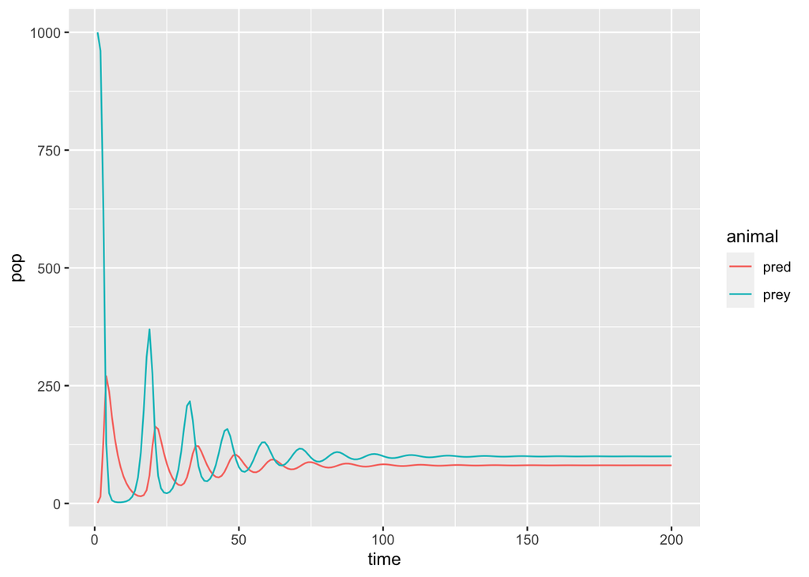

```r
source("lotvmod_hunt2.R") #raised hunting threshold to try to not have them all die? - raised and lowered


# set new parameter list
pars = data.frame(rprey=1.8,
                  alpha=0.01,
                  eff=0.3,
                  pmort=0.3,
                  K=2000,
                  h = 0.9)

# time
#hunting has a more noticeable effect before pop really stabilizes
days = seq(from=1,to=200)

# first see what happens when we start with 1 of each
currpop=c(prey=1000, pred=1)

# run differential equation solver
res = ode(func=lotvmod_hunt, y=currpop, times=days, parms=pars)

# extract the results
res_initial = as.data.frame(res) %>% gather(key="animal", value="pop",-time)

# graph both populations over time
p7 = ggplot(res_initial,
          aes(time, pop, col=animal)) +
  geom_line()

p7
```

The exploration above might be a bit hard to follow (sorry!) But I tried to document some of the things I was testing. I found that I really had to decrease the prey popiulation threshold for hunting to see major effects in the graphs. I also had trouble getting predator and prey populations to stabilize at high populatons, they seemed happiest around 100ish (or always below 500) - so the carrying capacity never really took effect in this model.

The if / else statement I originally had in the function was also causing issues where both populations could entirely die off - so I decidied to leave the simple model with hunting always incorporated

# Testing stability

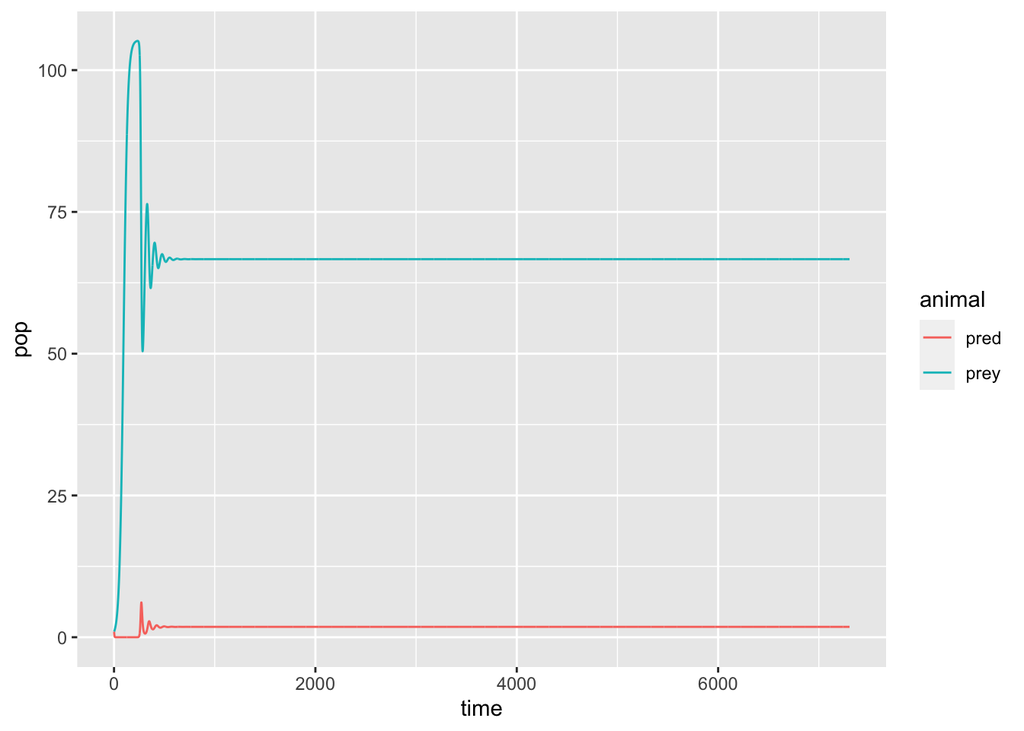

```r
# using original parameters to really focus on hunting effect
pars = data.frame(rprey=0.95,
                  alpha=0.01,
                  eff=0.6,
                  pmort=0.4,
                  K=2000,
                  h = 0.9)

# time - 20 years
days = seq(from=1,to=7305)

# first see what happens when we start with 1 of each
currpop=c(prey=1, pred=1)

# run differential equation solver
res = ode(func=lotvmod_hunt, y=currpop, times=days, parms=pars)

# extract the results
res_initial = as.data.frame(res) %>% gather(key="animal", value="pop",-time)

# graph both populations over time
p8 = ggplot(res_initial,
          aes(time, pop, col=animal)) +
  geom_line() +
  scale_x_continuous(limits = c(0, 7305))

p8
```

```r
source("lotvmod_hunt2.R")

# using original parameters to really focus on hunting effect
pars = data.frame(rprey=0.95,
                  alpha=0.01,
                  eff=0.6,
                  pmort=0.4,
                  K=2000,
                  h = 0.001) #starting with a really low hunting rate, jsut 0.1%

# time - 20 years
days = seq(from=1,to=7305)

# first see what happens when we start with 1 of each
currpop=c(prey=1, pred=1)

# run differential equation solver
res = ode(func=lotvmod_hunt, y=currpop, times=days, parms=pars)

# extract the results
res_initial = as.data.frame(res) %>% gather(key="animal", value="pop",-time)

# graph both populations over time
p_lowhunt = ggplot(res_initial,
          aes(time, pop, col=animal)) +
  geom_line() +
  scale_x_continuous(limits = c(0, 7305))
```

```r
# using original parameters to really focus on hunting effect
pars = data.frame(rprey=0.95,
                  alpha=0.01,
                  eff=0.6,
                  pmort=0.4,
                  K=2000,
                  h = 0.99) #really high hunting rate

# time - 20 years
days = seq(from=1,to=7305)

# first see what happens when we start with 1 of each
currpop=c(prey=1, pred=1)

# run differential equation solver
res = ode(func=lotvmod_hunt, y=currpop, times=days, parms=pars)

# extract the results
res_initial = as.data.frame(res) %>% gather(key="animal", value="pop",-time)

# graph both populations over time
p_highhunt = ggplot(res_initial,
          aes(time, pop, col=animal)) +
  geom_line() +
  scale_x_continuous(limits = c(0, 7305))
```

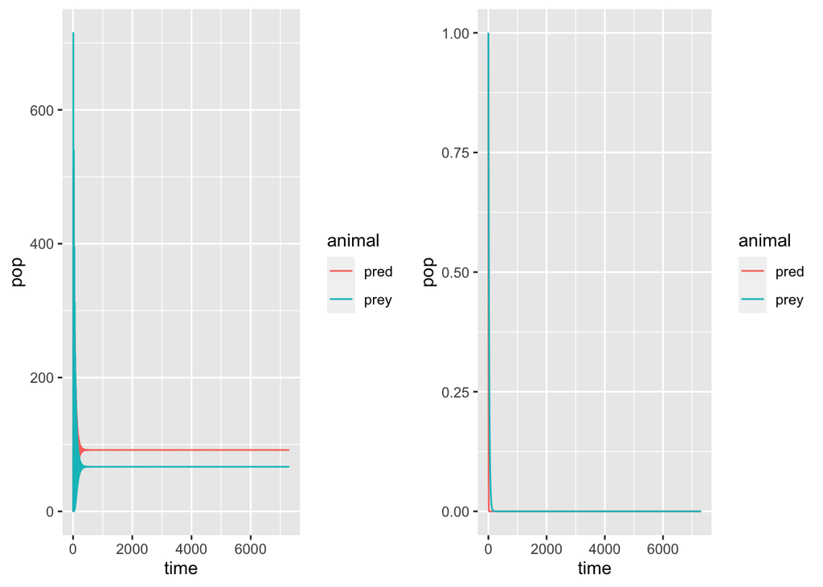

```r
ggarrange(p_lowhunt, p_highhunt)
```